# Lab 02 - Plastic waste

Otobo Ujah

1/31/2022

## Load packages and data

```r
knitr::opts_chunk$set(message = FALSE, warning = FALSE)
library(tidyverse)
```

```r
plastic_waste <- read.csv("C:/Users/Otobo/GitHub/progdata-class/data/data.csv")
```

## Exercises

### Exercise 1

Overall, the plastic waste per capita for countries in all continents were less than 1.0 kg per person with exception of North America where at least one country (Trinidad and Tobago) had a plastic waster per capita that great greater than 3.0kg per person

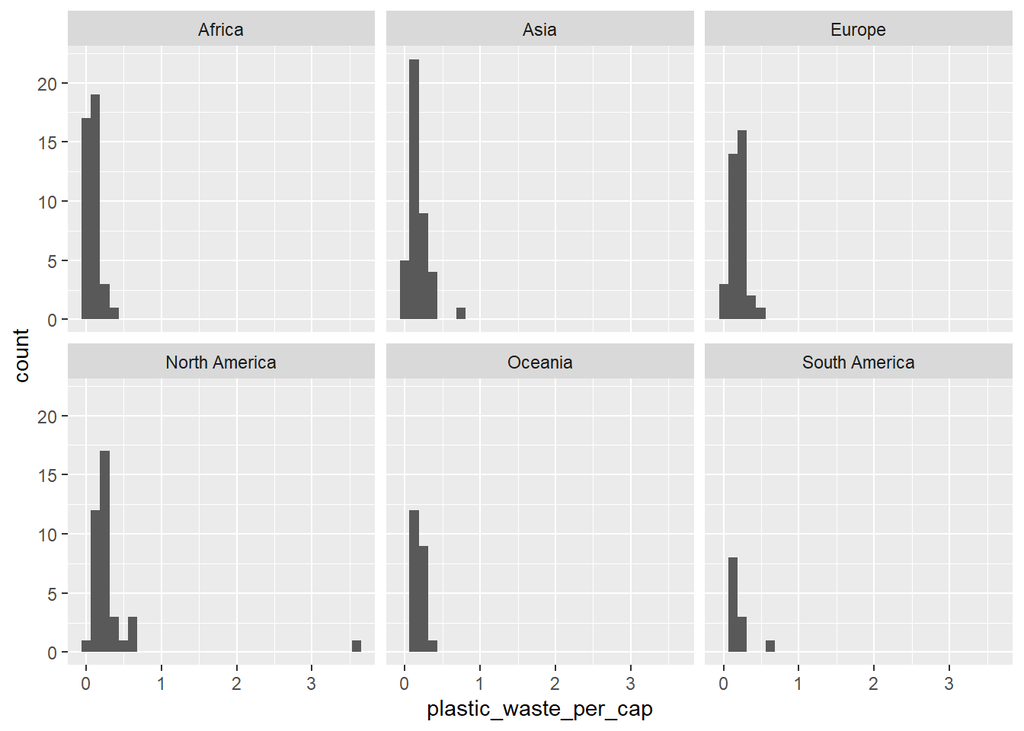

```r
ggplot(plastic_waste,
       aes(x = plastic_waste_per_cap)) +
  geom_histogram() +
  facet_wrap(~continent)
```

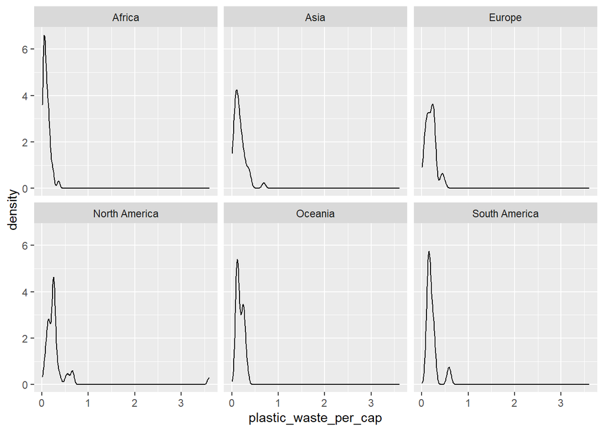

```r
ggplot(plastic_waste,
       aes(x = plastic_waste_per_cap)) +
  geom_density()+
  facet_wrap(~continent)
```

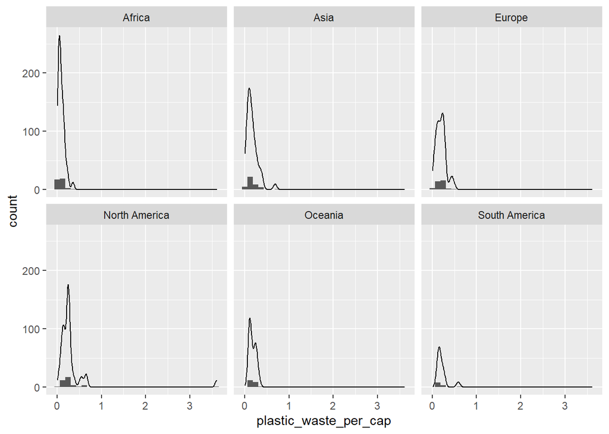

```r
ggplot(plastic_waste,
       aes(x = plastic_waste_per_cap)) +
  geom_histogram() +
  geom_density(aes(y = after_stat(count))) +
  facet_wrap(~continent)
```

### Exercise 2

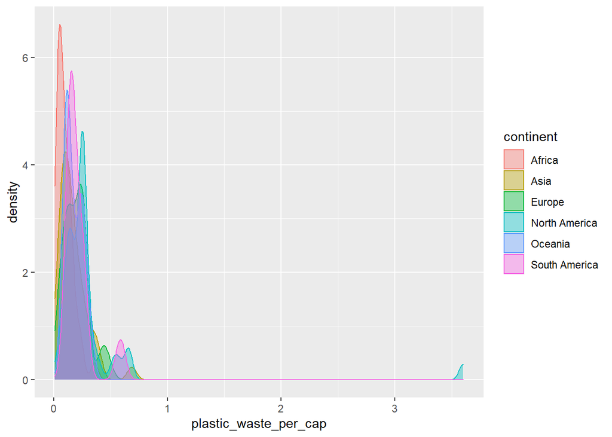

```r
ggplot(plastic_waste,
       aes(x = plastic_waste_per_cap, color = continent,fill = continent)) +
  geom_density(alpha = 0.4)
```

### Exercise 3

We defined color and fill of curves by mapping to the aesthetics to ensure that the boundaries for each continent have unique colors and the spaces within them are filled with the respective colors. However, we define alpha level to the geom to alter the level of opacity/transparency for each boundary in order to make them distinguishable. Applying the alpha level to the aes() in this case doesn’t result in the desired change in color.

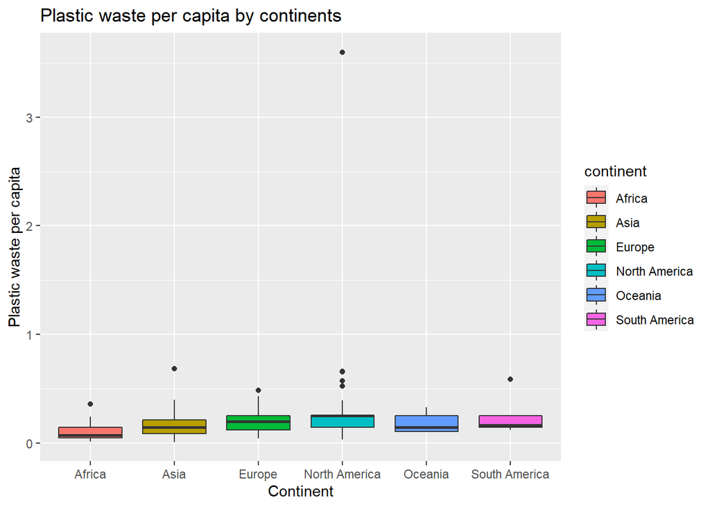

```r
ggplot(plastic_waste,
       aes(x = continent, y =  plastic_waste_per_cap, fill = continent)) +
  geom_boxplot() +
  labs(x = "Continent",
       y = "Plastic waste per capita",
       title = "Plastic waste per capita by continents")
```

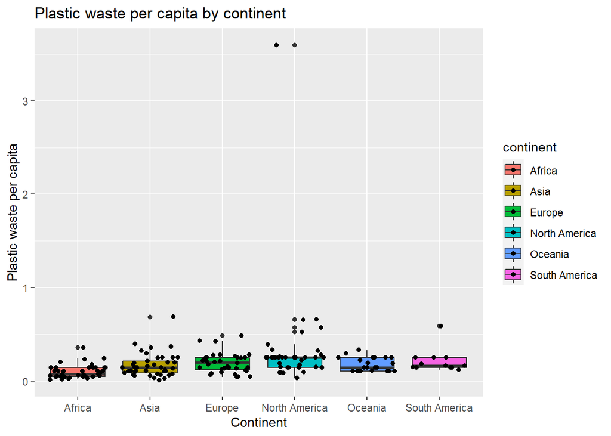

```r
ggplot(plastic_waste,
       aes(x = continent, y =  plastic_waste_per_cap, fill = continent)) +
  geom_boxplot()+
  geom_jitter() +
  labs(x = "Continent",
       y = "Plastic waste per capita",
       title = "Plastic waste per capita by continent")
```

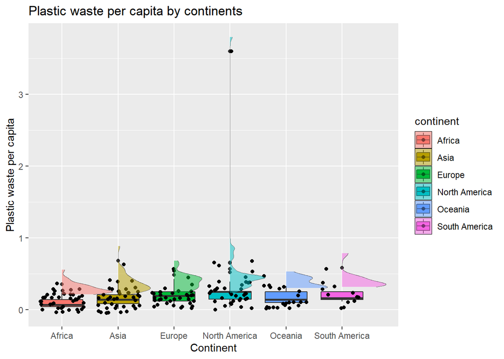

```r
ggplot(plastic_waste,
       aes(x = continent, y =  plastic_waste_per_cap, fill = continent)) +
  geom_boxplot(height = 0.15)+
  geom_jitter(height = 0.15) +
  ggdist::stat_slab(height = 0.3,
                    color = "black",
                    size = 0.2,
                    alpha = 0.5,
                    position = position_nudge(y=0.2)) +
  labs(x = "Continent",
       y = "Plastic waste per capita",
       title = "Plastic waste per capita by continents")
```

### Exercise 4

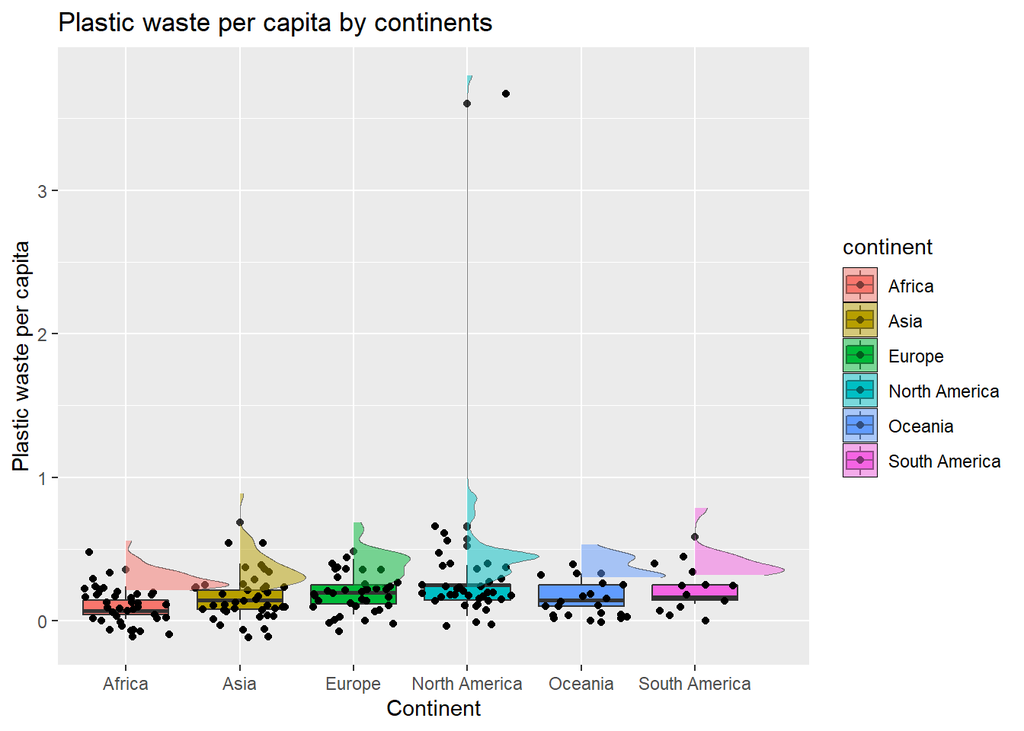

```r
ggplot(plastic_waste,
       aes(x = continent, y =  plastic_waste_per_cap, fill = continent)) +
  geom_boxplot(height = 0.15)+
  geom_jitter(height = 0.15) +
  ggdist::stat_slab(height = 0.3,
                    color = "black",
                    size = 0.2,
                    alpha = 0.5,
                    position = position_nudge(y=0.2)) +
  labs(x = "Continent",
       y = "Plastic waste per capita",
       title = "Plastic waste per capita by continents")
```

Although both density and boxplot are able to provide an idea of the nature of the distribution of plastic waste per capita (whether it is normally distributed or there are deviations from normality), the density plots give a better depiction of the skewness of the data.

### Exercise 5

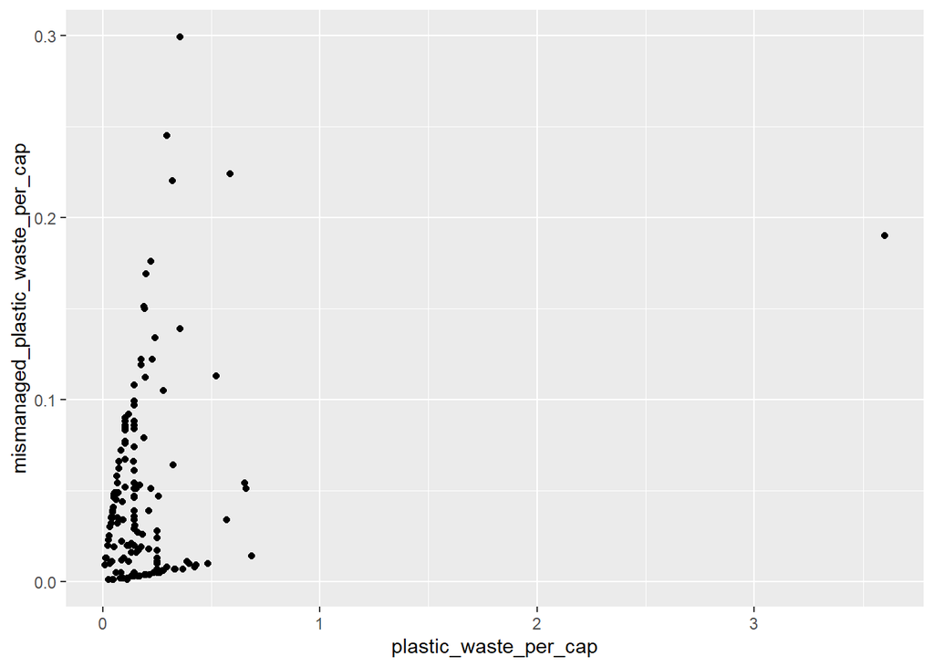

```r
ggplot(plastic_waste,
       aes(plastic_waste_per_cap,
           y = mismanaged_plastic_waste_per_cap)) +
  geom_point()
```

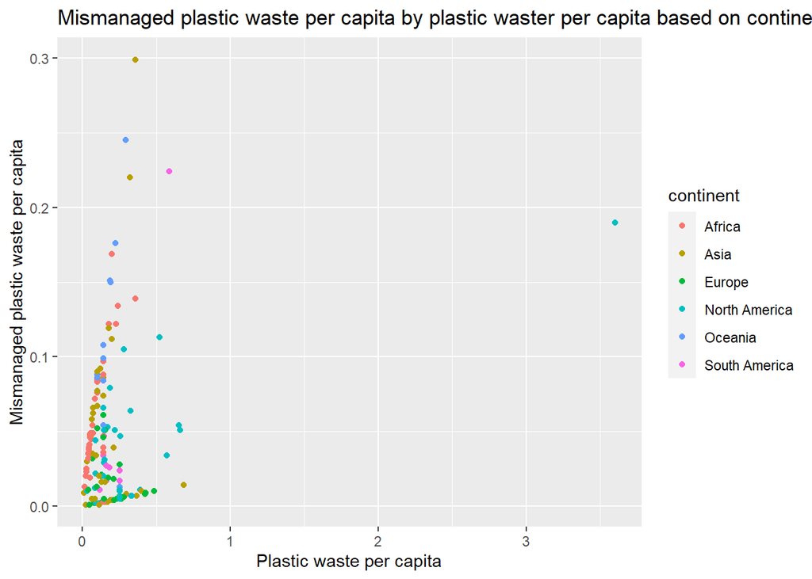

[output not shown]

```r
ggplot(plastic_waste,
       aes(plastic_waste_per_cap,
           y = mismanaged_plastic_waste_per_cap, color = continent)) +
  geom_point()+
  labs(x = "Plastic waste per capita",
       y = "Mismanaged plastic waste per capita",
       title = "Mismanaged plastic waste per capita by plastic waster per capita based on continents")
```

### Exercise 7

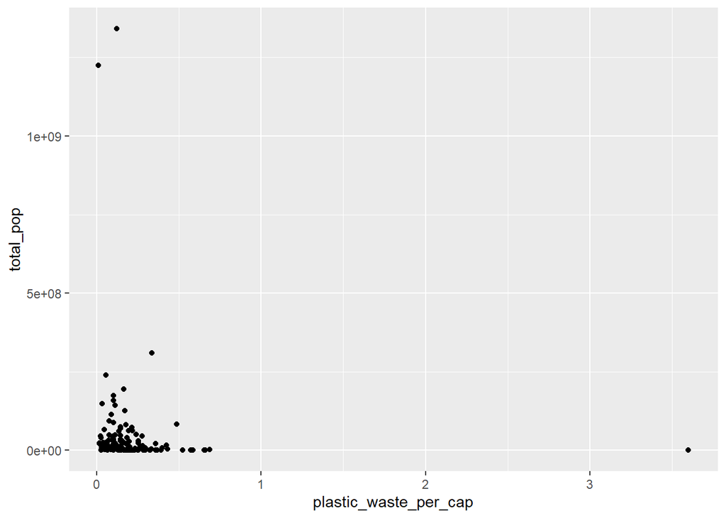

```r
ggplot(plastic_waste,
       aes(x = plastic_waste_per_cap, y = total_pop)) +
  geom_point()
```

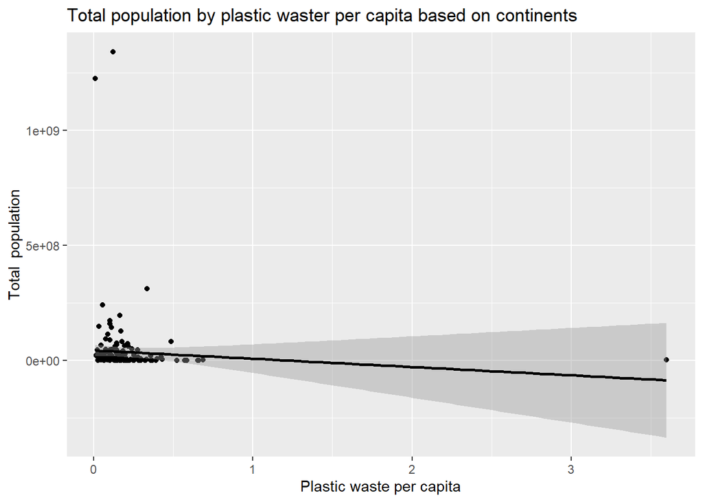

```r
  ggplot(plastic_waste,
       aes(x = plastic_waste_per_cap, y = total_pop)) +
  geom_point() +
  geom_smooth(method = "lm", color = "black") +
  labs(x = "Plastic waste per capita",
       y = "Total  population",
       title = "Total population by plastic waster per capita based on continents")
```

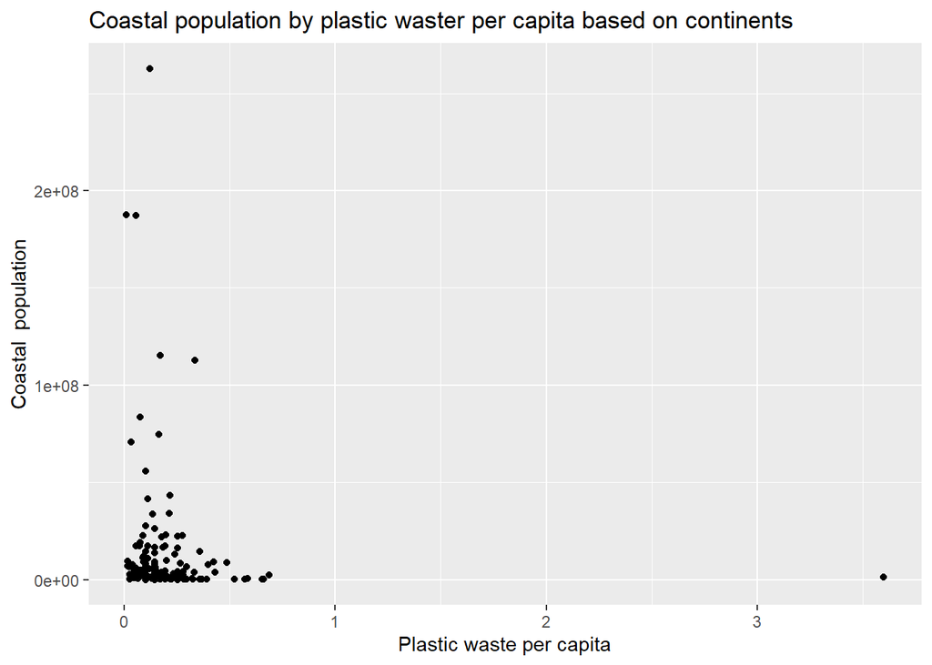

```r
ggplot(plastic_waste,
       aes(x = plastic_waste_per_cap, y = coastal_pop)) +
  geom_point() +
  labs(x = "Plastic waste per capita",
       y = "Coastal  population",
       title = "Coastal population by plastic waster per capita based on continents")
```

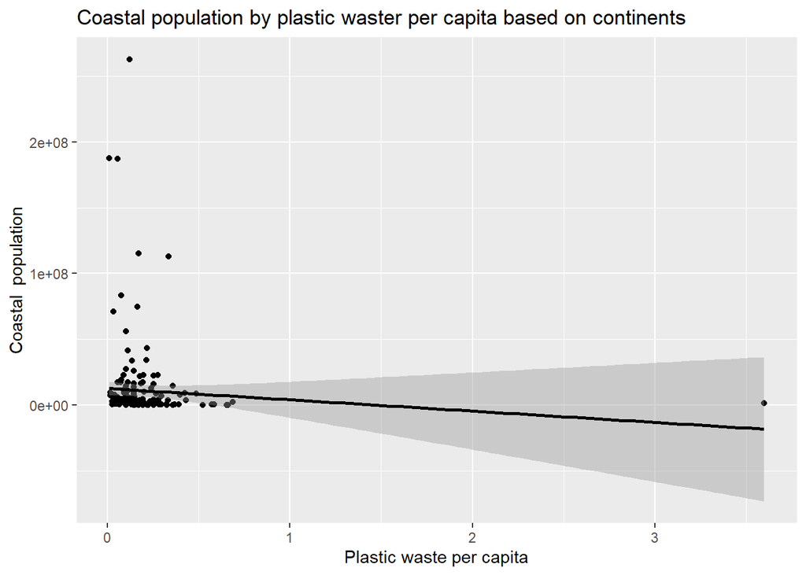

```r
ggplot(plastic_waste,
       aes(x = plastic_waste_per_cap, y = coastal_pop)) +
  geom_point() +
  geom_smooth(method= "lm", color = "black") +
  labs(x = "Plastic waste per capita",
       y = "Coastal  population",
       title = "Coastal population by plastic waster per capita based on continents")
```

### Exercise 8

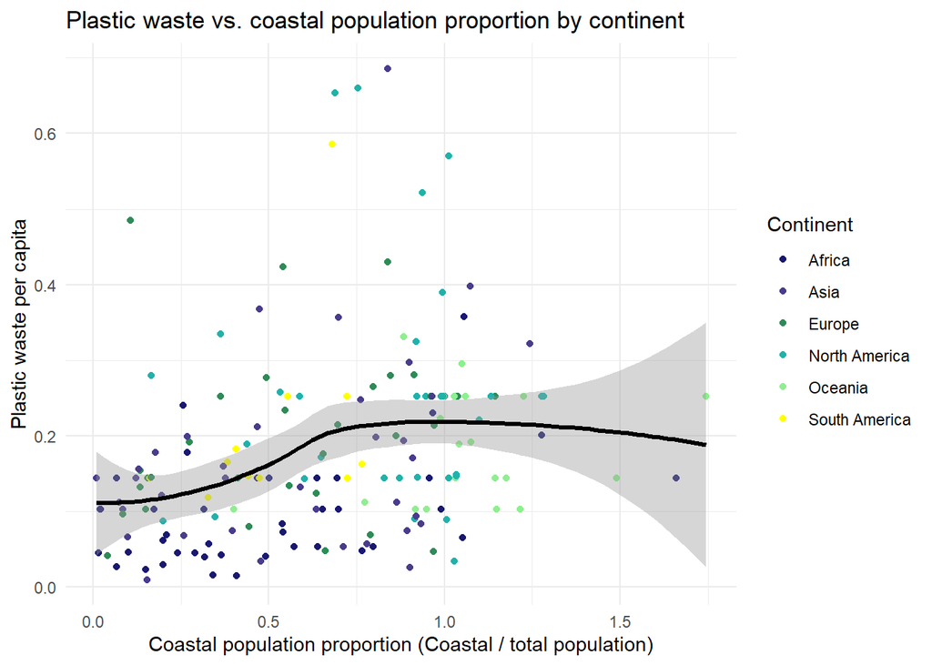

```r
ggplot(plastic_waste[plastic_waste$plastic_waste_per_cap < 3, ],
       aes(x = coastal_pop/total_pop, y = plastic_waste_per_cap, color = continent)) +
   theme_minimal() +
  geom_point() +
  geom_smooth(color = "black", size = 1.2) +
  scale_color_manual(name = "Continent",
                     values = c("Africa" = "midnightblue",
                                "Asia" = "darkslateblue",
                                "Europe" = "seagreen",
                                "North America" = "lightseagreen",
                                "Oceania" = "lightgreen",
                                "South America" = "yellow")) +
  labs(title = "Plastic waste vs. coastal population proportion by continent",
       x = "Coastal population proportion (Coastal / total population)",
       y = "Plastic waste per capita")
```

```r
# Helpful reference: https://stackoverflow.com/questions/45493163/ggplot-remove-na-factor-level-in-legend
```

```
For the plot above (ex. 8), there is a non-linear relationship between plastic waste per capita and the coastal population proportion. Specifically the correlation between this two variables are especially low majorly in Africa and Asia.
```

## Pro-Tips

### Excercise 3

Try this :D

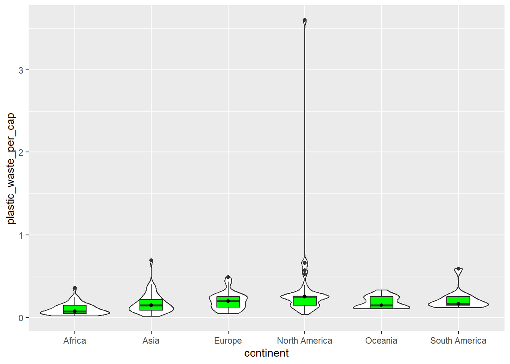

```r
ggplot(data = plastic_waste,
       mapping = aes(x = continent,
                     y = plastic_waste_per_cap)) +
  geom_violin()+
  geom_boxplot(width=.3, fill="green") +
  stat_summary(fun.y=median, geom="point")
```

Helpful reference:http://www.sthda.com/english/wiki/ggplot2-themes-and-background-colors-the-3-elements